# Why Comic Book Icons Are Mostly Male

Zitong Suo

### Male Dominance in the Comic Book Industry

When thinking about what the most famous comic book character is, people always mention Superman, Batman, Spider-Man, Nightwing, and Captain America, etc. Most of these iconic characters share one important trait: they are male. This is not merely a coincidence. In fact, male dominance has shaped the comic book industry for decades.

### Three Research Questions

This article will further explore this issue by three guided questions: what’s the proportion of new male and female characters introduced since 1961, what’s the gender distribution of good and bad characters across publishers, and whether male, female, or other/not specified gender characters receive more appearances per character among those who appear frequently.

These questions reveal how gender inequality is displayed in comic books through multiple dimensions. The first question focuses on how the degree of gender imbalances has changed over time. The second question explores how male and female characters are distributed across heroic and villainous roles and whether certain moral positions are associated with specific genders. The third question examines which gender of characters is given more visibility and influence by counting their frequencies. Through answering these questions, the gender inequality in comic books will be thoroughly uncovered.

### Dataset Description

The comic book characters data used in this article comes from the wiki database of two major publishers: DC and Marvel. Each observation represents a single character with categorical variables such as name, gender, alignment, publisher and numeric variables such as time information of first introduction and number of appearances, etc. This dataset allows for a comprehensive analysis of gender inequality existing in the comic book industry of the two biggest publishers from the 1930s to the 2010s.

### Trends in New Character Introductions Over Time

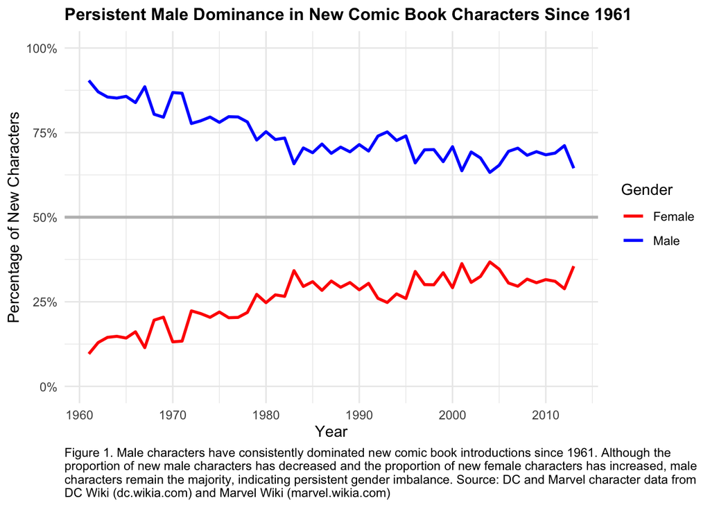

However, this progress has not fully resolved gender inequality in comic books. New male characters still account for a large proportion of new introductions, remaining above 50% for all the time, and this continues to reinforce the effects of historical gender imbalance in the industry. As a result, female characters, although improved, remains relatively low amount in the comic book industry.

### Gender Distribution Across Character Roles

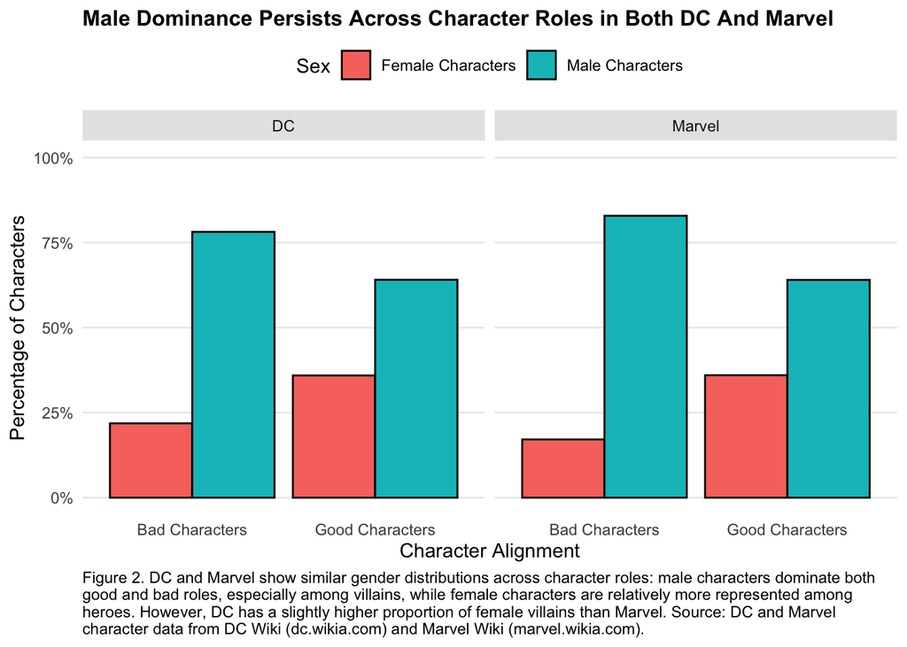

Figure 2 shows that male characters dominate both good and bad roles in DC and Marvel, with particularly high proportions among bad characters, where they account for roughly 80%. Female characters, by contrast, are more present among good characters than bad ones, but they have a relatively small proportion overall, making up roughly 30-35% of heroes and a small proportion of villains. This pattern reflects underlying gender stereotypes in comic book narratives. Female characters are relatively more related to heroic roles and less present among villains, which may reinforce stereotypes of women as morally good and supportive.

### Appearance Frequency Across Different Genders

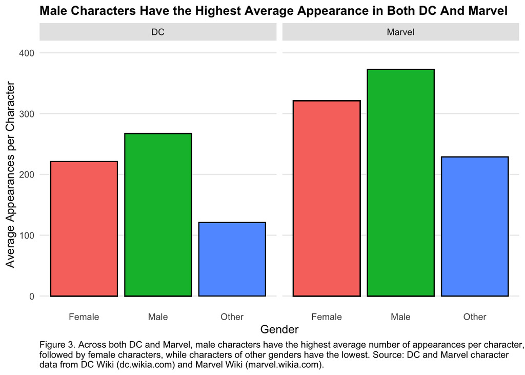

Figure 3 shows that male characters have the highest average number of appearances in both DC and Marvel, followed by female characters, while characters of other genders appear the least. Characters who appear more often are more likely to have an important role in the storyline. As a result, male characters are more likely to be perceived as main characters in the storyline. Because female and other gender characters appear less frequently, they may seem less important and are less likely to leave a strong impression on readers compared to male characters. This answers why, when people think about comic book characters, they are more likely to mention well-known male figures first.

### Persistent Gender Inequality in the Comic Book Industry And Its Influence

Overall, these three visualizations show that male dominance has been a consistent pattern in comic books since 1961. Not only do male characters make up the majority of new introductions and dominate both good and bad roles, but they also take central roles in the storyline. Although there has been some progress in increasing the number of new female characters, gender inequality remains a significant issue in comic books. Because comic books shape popular culture and influence social values, improving gender representation in comic books needs to be taken seriously and addressed carefully.